# Multi-species occupancy; Rota walkthrough. Christian Anderson 5/24/2023

# Rota multi-species occupancy walkthrough

### ( https://www.youtube.com/watch?v=tj_OCO77_sc ) Christian Anderson 5/24/2023

Read in detection/non-detection data

```r
#V1-V3 = weeks surveyed
#rows = cameras
bob <- read.csv('multiple species occupancy walkthrough/data/bobcat_3wk.csv', header = F)
```

site level covariate data (covariates that only vary by site but stay constant for duration of survey)

- Dist_5km = proportion disturbance within 5km
- HDens_5km = housing density within 5km
- latitude / longitude = latitude and longitude (div by 100)
- People_site = total people recorded / 1000
- trail = binary indicator of wheter camera was on trail (1) or not (0)

```r
occ_covs <- read.csv('data/psi_cov3wk.csv')
head(occ_covs)
```

|  | Dist_5km | HDens_5km | Latitude | Longitude | People_site | Trail |
| --- | --- | --- | --- | --- | --- | --- |
| 1 | 0.04 | 9.345258 | 0.3899441 | -0.7723958 | 0.857 | 1 |
| 2 | 0.03 | 9.499197 | 0.3899250 | -0.7723920 | 0.002 | 0 |
| 3 | 0.03 | 9.647173 | 0.3899111 | -0.7723954 | 0.387 | 1 |
| 4 | 0.03 | 9.598066 | 0.3899166 | -0.7723972 | 0.003 | 0 |
| 5 | 0.03 | 9.607825 | 0.3899179 | -0.7724004 | 0.000 | 0 |
| 6 | 0.03 | 9.748791 | 0.3899058 | -0.7724046 | 0.443 | 1 |

```r
NA
NA
NA
```

read in detection level covariate on column for every repliacte survey; average temperature over one week replicate period (example of covariate that changes from detection to detection)

```r
det_covs <- read.csv('data/detection data.csv')
head(det_covs)
```

apply unmarked package

```r
library(unmarked)
```

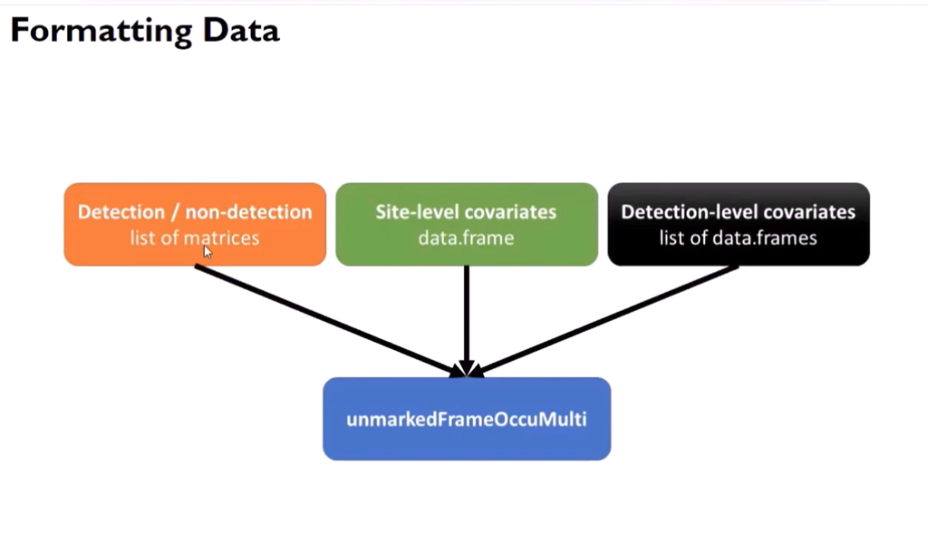

place detection/non-detection into a named list

```r
#each element of list must be a matrix
y_list <- list(bobcat = as.matrix(bob),
               coyote = as.matrix(coy),
               redfox = as.matrix(fox))
```

Place detection covariates into a named list

```r
#each element of the list must be of the same dimension as each detection / non-detection mstrix
  #same num of rows (each site) and columns(repl survey)

det_list <- list(temp= det_covs)
  #temperature is a covariate that can change based on when there is a instance of detection
```

combine data into an unmarkedFrameOccuMulti object:

```r
#fn+f1 pulls up help menu
msom_data <- unmarkedFrameOccuMulti(y = y_list,
                                    siteCovs= occ_covs,
                                    obsCovs = det_list)
```

### Intercept only model, assuming independence

#### Syntax similar to other models

- need detection formula for each species
- need occupancy formula for each natural parameter included in model (3)
- need formulas (specified as character vector)
- need order of formulas follows detection / non-detection list (bob, coy, fox

### Fit a Model

intercept only model that assumes independence among species. We do this by only allowing 1st order natural paramaters (maxOrder = 1) **assumes species occur independently at each site**

- essentially the same as fitting three single species occupancy models

```r
fit_1 <- occuMulti(detformulas = c('~1', '~1', '~1'),
                   stateformulas = c('~1', '~1', '~1'),
                   maxOrder = 1,
                   data = msom_data)
            #state formulas len=3 so three natural parameters, i,e. three species
            #maxOrder = 1 makes it so that the model ignores natural params above              first order> assumes species occur independently at each site
```

This is equivalent to fitting 3 single-species occupancy models

```r
summary(fit_1)
```

### Intercept-only model, assuming dependence

- set maxOrder = 2 to estimate up to 2nd order nat. params
- permits dependence between species
- fixes all nat params > maxOrder at 0

```r
fit_2 <- occuMulti(detformulas = c('~1', '~1', '~1'),
                   stateformulas = c('~1', '~1', '~1',
                                     '~1', '~1', '~1'),
                   maxOrder = 2,
                   data = msom_data)
                #State Formulas> there are three choose two different possiblities,                   one for each combo
                #maxOrder = 2 sets natural parameters to 2nd order which allows for                   pairwise interactions between species
```

#### Output interpretation

(Estimate = slope coefficient )

- bobcat and coyote occur together more frequently than expected by chance (p<0.01)
- bobcat and red fox occur together less frequently than expected by chance (p<0.01)
- coyote and red fox occur together more frequently than expected by chance (p<0.01)
- AIC strongly favors the model incorporating dependence AIC= 6626.111 for fit_2 and AIC= 6710.658 for fit_1; it’s much smaller

### Incorporating Covariates

- any param can be modeled as a function of covariates
- covariate models for each param can be unique
- names of detection covariates correspond to names provided in named list
- names of occupancy covariates correspond to names in data.frame

```r
fit_3 <- occuMulti(detformulas = c('~temp', '~1', '~1'),
                   stateformulas = c(  '~Dist_5km', '~HDens_5km', '~People_site',
                                     '~Latitude', '~1', '~1'),
                   maxOrder = 2,
                   data = msom_data)
```

```
'Call:
occuMulti(detformulas = c("~temp", "~1", "~1"), stateformulas = c("~Dist_5km",      "~HDens_5km", "~People_site", "~Latitude", "~1", "~1"), data = msom_data,      maxOrder = 2)

Occupancy (logit-scale):                                                                                       Estimate      SE      z  P(>|z|)
[bobcat] (Intercept)         -1.35970 0.19131  -7.11 1.18e-12
[bobcat] Dist_5km           -22.95531 5.90074  -3.89 1.00e-04

##                          ^log odds that a bobcat occurs at a location under the condition that all other species are absent

[coyote] (Intercept)         -1.48520 0.17195  -8.64 5.74e-18
[coyote] HDens_5km            0.00424 0.00232   1.83 6.74e-02
[redfox] (Intercept)         -2.45677 0.16226 -15.14 8.71e-52
[redfox] People_site          5.92772 1.27022   4.67 3.06e-06

[bobcat:coyote] (Intercept)   8.89548 2.78768   3.19 1.42e-03
[bobcat:coyote] Latitude    -18.97578 7.30114  -2.60 9.35e-03
##                            ^moving north, bobcat less likely occupy the same site as a coyote

[bobcat:redfox] (Intercept)  -1.55839 0.42126  -3.70 2.16e-04
[coyote:redfox] (Intercept)   1.55320 0.26507   5.86 4.64e-09

Detection (logit-scale):                      Estimate     SE     z  P(>|z|) [bobcat] (Intercept)   -1.248 0.1439 -8.67 4.16e-18
[bobcat] temp          -0.306 0.0848 -3.60 3.12e-04
[coyote] (Intercept)   -0.322 0.0756 -4.26 2.05e-05
[redfox] (Intercept)   -0.494 0.1295 -3.81 1.36e-04

AIC: 6544.769
Number of sites: 1437
optim convergence code: 0
optim iterations: 133
Bootstrap iterations: 0
```

#### Sample interpretations:

- for every I-unit increase disturbance within 5km, the log odds of bobcat occurance, when *coyote and red fox are absent,* declines by 22.96
- When latitude = 0, bobcats are more likely to occur at a site when coyotes are present (and vice versa, p<0.01)
- For every I unit increase in Latitude, the log odds bobcats will occur at a site decreases by 18.98 if coyotes are also present, relative to equivalent sites where coyotes are absent
  - *i.e., as we move north, bobcats and coyotes are less likely to occupy the same site*
- For every I-unit increase in temperature, the log odds of bobcat detection decreases by 0.31

### Conditional occupancy probability

Calculation of conditional and marginal occupancy probabilities is done with predict function

- create a data.frame for predictions
  - the procedure is equivalent to creating data frames for all other applications of predict
- Include complete range of observed latitude; hold all other variables at their mean

```r
nd_cond <- data.frame(
  Dist_5km = rep(mean(occ_covs$Dist_5km), 100),
  HDens_5km = rep(mean(occ_covs$HDens_5km), 100),
  People_site = rep(mean(occ_covs$People_site), 100),
  Latitude = seq(min(occ_covs$Latitude), max(occ_covs$Latitude),
                 length.out = 100)
)
```

### Conditional occupancy probability

### Predicting bobcat occurance when coyotes are present

- <species> indicates which species we assume when predicting occupancy
- <cond> indicateswhich species we are assuming is present or absent

````
```r
bob_coy_1 <- predict(fit_3, type = 'state' ,species = 'bobcat',
                     cond = 'coyote', newdata = nd_cond)
  #what is the probability that a bobcat will be at a site on the condition that a coyote was present at that site

## Bootstrapping confidence intervals with 100 samples

```
````

#### Predicting bobcat occurrence when coyotes are absent

- putting a - in front of coyote tells *predict* you wish to assume coyotes are absent

```r
bob_coy_0 <- predict(fit_3, type = 'state', species = 'bobcat',
                     cond = '-coyote', newdata = nd_cond)
  #condition on coyote being absent

## Bootstrapping confidence intervals with 100 samples
```

#### Plotting

```r
gg_df_cond <- data.frame(
  latitude = rep(nd_cond$Latitude, 2),
  occupancy = c(bob_coy_1$Predicted,
                bob_coy_0$Predicted),
  low = c(bob_coy_1$lower,
          bob_coy_0$lower),
  high = c(bob_coy_1$upper,
           bob_coy_0$upper),
  conditional = rep(c('Coyote present', 'Coyote absent'),
                    each = 100)
)
```

```r
library(ggplot2)

cond_fig <- ggplot(gg_df_cond, aes(x= latitude, y= occupancy,
                                   group = conditional)) +
  geom_ribbon(aes(ymin = low, ymax = high, fill = conditional)) +
  geom_line() +
  ylab('Conditional bobcat/noccupancy probability') +
  xlab('Latitude') +
  labs(fill = 'Coyote state') +
  theme(text = element_text(size = 25),
        legend.position = c(0.75, 0.85))
```

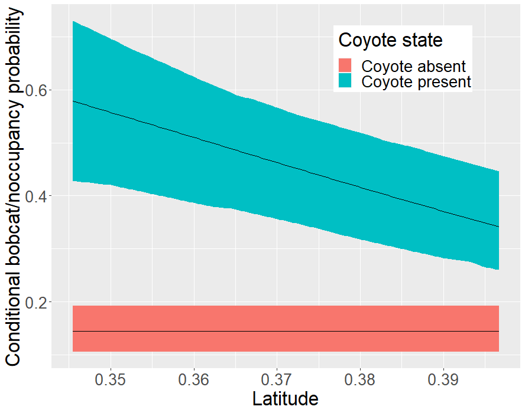

#### Marginal occupancy probability

```r
nd_marg <- data.frame(
  Dist_5km = seq(min(occ_covs$Dist_5km), max(occ_covs$Dist_5km),
                 length.out = 100),
  HDens_5km = rep(mean(occ_covs$HDens_5km), 100),
  People_site = rep(mean(occ_covs$People_site), 100),
  Latitude = rep(mean(occ_covs$Latitude), 100)
)
```

omitting the conditional argument to calculate marginal occupancy probability

```r
bob_marg <- predict(fit_3, type = 'state', species = 'bobcat',
                    newdata = nd_marg)
```

#### figure

```r
gg_df_marg <- data.frame(
  hd = nd_marg$Dist_5km,
  occupancy = bob_marg$Predicted,
  low = bob_marg$lower,
  high = bob_marg$upper

)
```

```r
marg_fig <- ggplot(gg_df_marg, aes(x = hd, y= occupancy)) +
  geom_ribbon(aes(ymin = low, ymax = high), alpha = .5) +
  geom_line() +
  ylab('Marginal bobcat\noccupancy probability') +
  theme(text = element_text(size = 25))
```

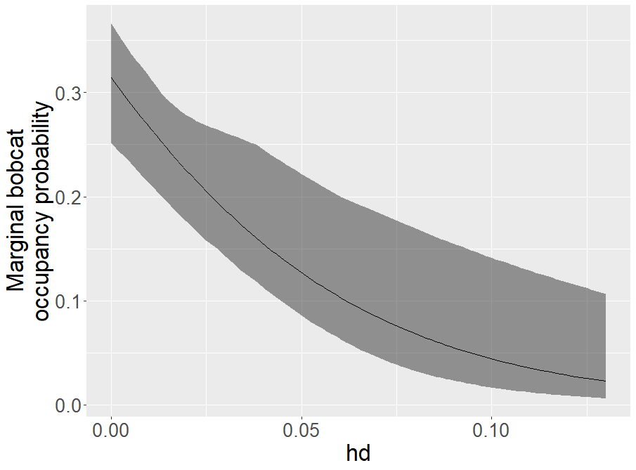